# homework4

Qiyao Jiang

2025-06-30

## R Markdown

```r
library(tidyverse)
ckm_nodes <- read_csv("data/ckm_nodes.csv")
dim(ckm_nodes)
```

```
## [1] 246  13
```

```r
colnames(ckm_nodes)
```

```
##  [1] "city"                         "adoption_date"
##  [3] "medical_school"               "attend_meetings"
##  [5] "medical_journals"             "free_time_with"
##  [7] "discuss_medicine_socially"    "club_with_drs"
##  [9] "drs_among_three_best_friends" "practicing_here"
## [11] "office_visits_per_week"       "proximity_to_other_drs"
## [13] "specialty"
```

```r
ckm_network <- read.table("data/ckm_network.dat", header=F)
dim(ckm_network)
```

```
## [1] 246 246
```

```r
mutate(ckm_nodes, doctor_id = row_number()) -> ckm_nodes
filter(ckm_nodes, !is.na(adoption_date)) -> ckm_nodes


any(is.na(ckm_nodes$adoption_date))
```

```
## [1] FALSE
```

```r
expanded_df <- ckm_nodes |>
  crossing(month = 1:17)

mutate(ckm_network, doctor_id = row_number()) -> ckm_network

ckm_network |>
  filter(row_number() %in% ckm_nodes$doctor_id) |>
  dplyr::select(doctor_id, everything()) ->ckm_network
```

2125 = 125 * 17, 6: doctor_id & month & four_observations

```r
record <- expanded_df |>
  mutate(
    began_adoption = ifelse(month==adoption_date, T, F),
    whether_adopted_before = ifelse(month>adoption_date, T, F),
  ) |>
  dplyr::select(doctor_id, adoption_date, began_adoption, whether_adopted_before, month)

arrange(record, doctor_id)
```

```
## # A tibble: 2,125 × 5
##    doctor_id adoption_date began_adoption whether_adopted_before month
##        <int>         <dbl> <lgl>          <lgl>                  <int>
##  1         1             1 TRUE           FALSE                      1
##  2         1             1 FALSE          TRUE                       2
##  3         1             1 FALSE          TRUE                       3
##  4         1             1 FALSE          TRUE                       4
##  5         1             1 FALSE          TRUE                       5
##  6         1             1 FALSE          TRUE                       6
##  7         1             1 FALSE          TRUE                       7
##  8         1             1 FALSE          TRUE                       8
##  9         1             1 FALSE          TRUE                       9
## 10         1             1 FALSE          TRUE                      10
## # ℹ 2,115 more rows
```

```r
record |>
  group_by(month) |>
  mutate(
    num_of_connection_b4 =  as.numeric(t(ckm_network[, doctor_id+1]) %*% whether_adopted_before),
    num_of_connection = as.numeric(t(ckm_network[, doctor_id+1]) %*% (whether_adopted_before + began_adoption)),
  ) |>
  dplyr::select(!adoption_date) |>
  dplyr::select(doctor_id, month, everything())-> record
arrange(record, doctor_id) ->record
head(record, 20)
```

```
## # A tibble: 20 × 6
## # Groups:   month [17]
##    doctor_id month began_adoption whether_adopted_before num_of_connection_b4
##        <int> <int> <lgl>          <lgl>                                 <dbl>
##  1         1     1 TRUE           FALSE                                     0
##  2         1     2 FALSE          TRUE                                      0
##  3         1     3 FALSE          TRUE                                      2
##  4         1     4 FALSE          TRUE                                      2
##  5         1     5 FALSE          TRUE                                      2
##  6         1     6 FALSE          TRUE                                      2
##  7         1     7 FALSE          TRUE                                      2
##  8         1     8 FALSE          TRUE                                      2
##  9         1     9 FALSE          TRUE                                      2
## 10         1    10 FALSE          TRUE                                      2
## 11         1    11 FALSE          TRUE                                      2
## 12         1    12 FALSE          TRUE                                      2
## 13         1    13 FALSE          TRUE                                      2
## 14         1    14 FALSE          TRUE                                      2
## 15         1    15 FALSE          TRUE                                      2
## 16         1    16 FALSE          TRUE                                      2
## 17         1    17 FALSE          TRUE                                      3
## 18         2     1 FALSE          FALSE                                     0
## 19         2     2 FALSE          FALSE                                     0
## 20         2     3 FALSE          FALSE                                     0
## # ℹ 1 more variable: num_of_connection <dbl>
```

3.(a)because the maximum number of connection of a doctor is 28(outlier), and 75% of doctors have a total connection number below 10, we don’t have enough data to estimate the value of p_k and q_k for k>21

```r
mutate(ckm_network, total_connection = rowSums(dplyr::select(ckm_network, !doctor_id))) -> ckm_network
```

```r
max(ckm_network$total_connection)
```

```
## [1] 28
```

```r
median(ckm_network$total_connection)
```

```
## [1] 7
```

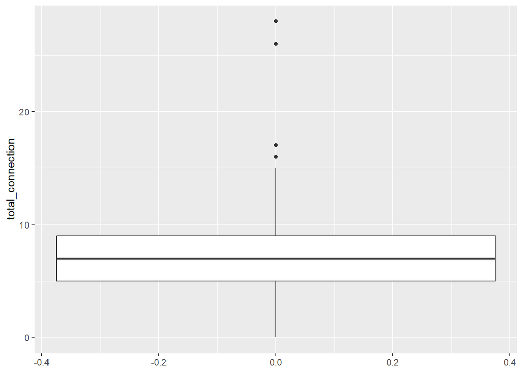

```r
ggplot(ckm_network, aes(y=total_connection)) +
  geom_boxplot()
```

```r
record |>
  filter(whether_adopted_before==F) |>
  group_by(num_of_connection_b4) |>
  summarize(
    total = n(),
    freq = sum(began_adoption),
    p = freq/total
  ) -> p_k.df

record |>
  filter(whether_adopted_before==F) |>
  group_by(num_of_connection) |>
  summarize(
    total = n(),
    freq = sum(began_adoption),
    q = freq/total
  ) ->q_k.df
```

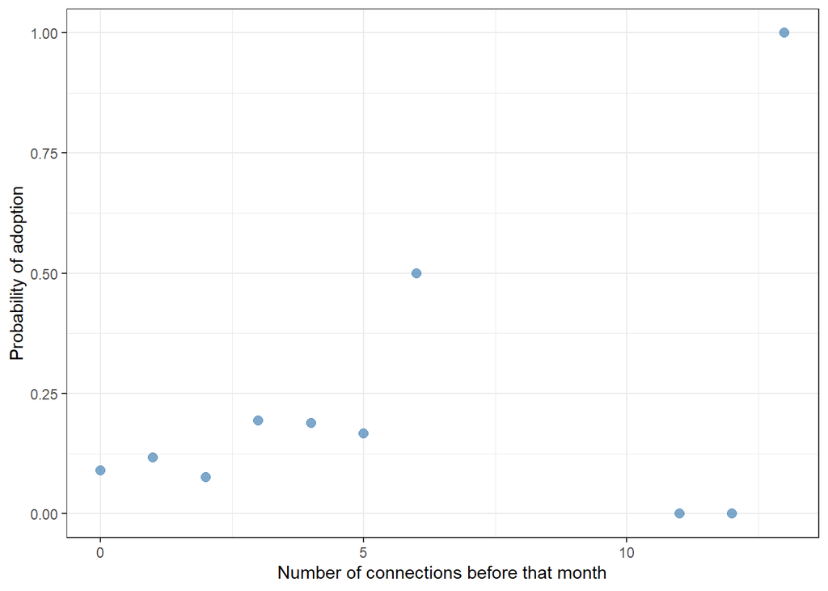

```r
ggplot(p_k.df, aes(x=num_of_connection_b4, y=p)) +
  geom_point(alpha=0.7, size=2.5, color="steelblue") +
  labs(x="Number of connections before that month", y="Probability of adoption") +
  theme_bw()
```

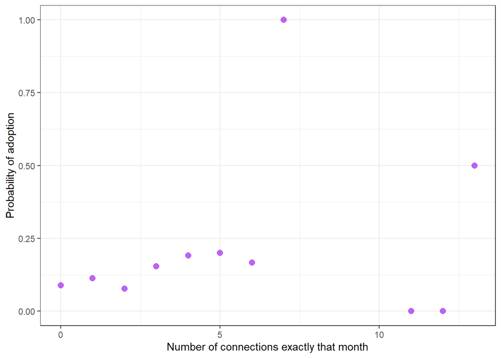

```r
ggplot(q_k.df, aes(x=num_of_connection, y=q)) +
  geom_point(alpha=0.7, size=2.5, color="purple") +
  labs(x="Number of connections exactly that month", y="Probability of adoption") +
  theme_bw()
```

4. (a)linear model

```r
linear.model <- lm(p ~ num_of_connection_b4, p_k.df)
summary(linear.model)
```

```
##
## Call:
## lm(formula = p ~ num_of_connection_b4, data = p_k.df)
##
## Residuals:
##      Min       1Q   Median       3Q      Max
## -0.39517 -0.05865  0.00154  0.02362  0.57915
##
## Coefficients:
##                      Estimate Std. Error t value Pr(>|t|)
## (Intercept)           0.08707    0.15176   0.574    0.582
## num_of_connection_b4  0.02568    0.02095   1.226    0.255
##
## Residual standard error: 0.2963 on 8 degrees of freedom
## Multiple R-squared:  0.1581, Adjusted R-squared:  0.0529
## F-statistic: 1.503 on 1 and 8 DF,  p-value: 0.2551
```

the estimated intercept is 0.087, and estimated slope is 0.026; however the p-value is large(for slope it’s 0.255>0.05), which might be caused by those outlier data pionts which is generated by a rather small amount of sample number. Try to filter by “total > 15”:

```r
linear.model.beta <- lm(p ~ num_of_connection_b4, filter(p_k.df, total > 15))
summary(linear.model.beta)
```

```
##
## Call:
## lm(formula = p ~ num_of_connection_b4, data = filter(p_k.df,
##     total > 15))
##
## Residuals:
##         1         2         3         4         5         6
##  0.002698  0.008536 -0.052357  0.044943  0.019554 -0.023373
##
## Coefficients:
##                      Estimate Std. Error t value Pr(>|t|)
## (Intercept)          0.088019   0.027488   3.202   0.0328 *
## num_of_connection_b4 0.020404   0.009079   2.247   0.0879 .
## ---
## Signif. codes:  0 '***' 0.001 '**' 0.01 '*' 0.05 '.' 0.1 ' ' 1
##
## Residual standard error: 0.03798 on 4 degrees of freedom
## Multiple R-squared:  0.5581, Adjusted R-squared:  0.4476
## F-statistic: 5.051 on 1 and 4 DF,  p-value: 0.0879
```

now we have a p-value close to 0.05 and a R2 value of 0.56, suggesting that the number of connection is a not-bad predictor

(b)this advanced model tries to map p_k into a value between 0 and 1. we reformulate this formula into log(p/(1-p)) = a+b*k to make it easier for model fitting

```r
logit.model <- lm(log(p/(1-p))~num_of_connection_b4, filter(p_k.df, total > 15))
summary(logit.model)
```

```
##
## Call:
## lm(formula = log(p/(1 - p)) ~ num_of_connection_b4, data = filter(p_k.df,
##     total > 15))
##
## Residuals:
##        1        2        3        4        5        6
##  0.02538  0.13033 -0.51783  0.37195  0.16136 -0.17120
##
## Coefficients:
##                      Estimate Std. Error t value Pr(>|t|)
## (Intercept)          -2.33029    0.25057  -9.300 0.000744 ***
## num_of_connection_b4  0.17841    0.08276   2.156 0.097359 .
## ---
## Signif. codes:  0 '***' 0.001 '**' 0.01 '*' 0.05 '.' 0.1 ' ' 1
##
## Residual standard error: 0.3462 on 4 degrees of freedom
## Multiple R-squared:  0.5374, Adjusted R-squared:  0.4218
## F-statistic: 4.647 on 1 and 4 DF,  p-value: 0.09736
```

the result shows that the number of connection has a marginal significance(p-value=0.097<0.1) to the variance of adoption rate

(c)plot

```r
new_data <- data.frame(num_of_connection_b4 = seq(from=min(p_k.df$num_of_connection_b4), to=max(p_k.df$num_of_connection_b4), length.out=200))
new_data$linear.pred.p <- predict(linear.model, newdata=new_data)
logit.pred <- predict(logit.model, newdata=new_data)
new_data$logit.pred.p <- exp(logit.pred)/(1+exp(logit.pred))
new_data |>
  pivot_longer(
    cols = c("linear.pred.p", "logit.pred.p"),
    names_to = "model",
    values_to = "p"
  ) -> new_data
```

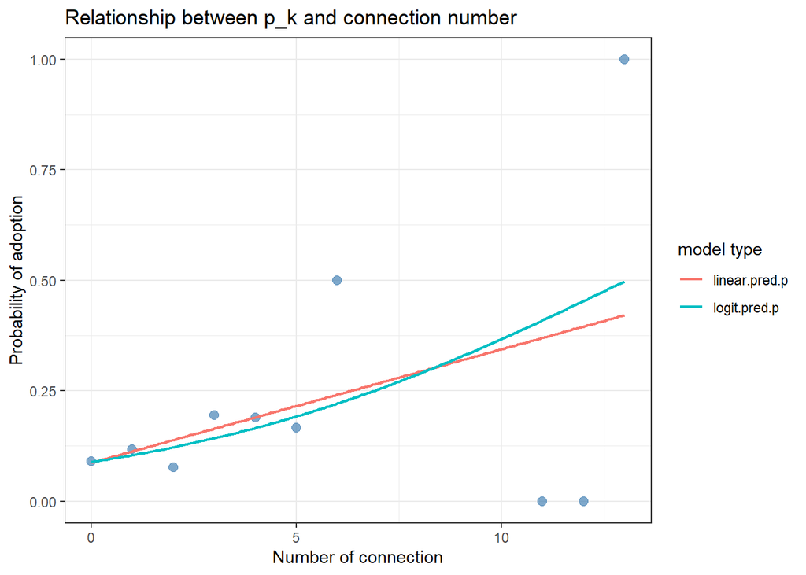

```r
ggplot(p_k.df, aes(x=num_of_connection_b4, y=p)) +
  geom_point(alpha=0.7, size=2.5, color="steelblue") +
  geom_line(data=new_data, aes(x=num_of_connection_b4, y=p, color=model), linewidth=0.75) +
  labs(x="Number of connection", y="Probability of adoption", title="Relationship between p_k and connection number", color="model type") +
  theme_bw()
```

I would prefer the logit model, as it only outputs a predicted p-value between 0 and 1, so it’s capable of scaling to large connection numbers.